# Experimentos com um fator: análise de variância

Rumenick Pereira da Silva

28 de abril de 2019

## Problema 1

Um artigo publicado na *Environment International* (Vol. 18, No. 4, 1992) decreve um experimento, em que é investigado a quantidade de radônio (um gás radioativo que pode causar câncer) liberada em chuveiros. Para a realização desse, utilizou-se água enriquecida com radônio e seis diâmetros de orifício diferentes foram testados nos chuveiros. Os dados do experimento são apresentados na tabela seguinte (tradução nossa do exercício 3-9 de Montgomery, 1997,p. 120-121):

| Diâmetro do orifício | Concentração de radônio (%) |
| --- | --- |
| 0,37 | 80 —- 83 —- 83 —- 85 |
| 0,51 | 75 —- 75 —- 79 —- 79 |
| 0,71 | 74 —- 73 —- 76 —- 77 |
| 1,02 | 67 —- 72 —- 74 —- 74 |
| 1,40 | 62 —- 62 —- 67 —- 69 |
| 1,99 | 60 —- 61 —- 64 —- 66 |

1. O diâmetro do orifício influência na concentração de radônio liberada? Use $\alpha = 0,05$;
2. Encontre o p-valor associado a estatística $F$ obtida no item (a).
3. Faça a análise dos resíduos desse experimento.
4. Obtenha o intervalo de 95% de confiança para concentração média de radônio liberada quando o diâmetro do orifício é de 1,40.
5. Por fim, construa um gráfico para comparar as médias dos tratamentos (Diâmetro do orifício) como descrito na Seção 3-5.3 (Montgomery, 1997, p. 89 - 90). Quais conclusões você tirar?

### Solucionando o problema 1

#### Hipóteses a serem testadas:

- Em português
  - $H_{0}$: não há diferença na concentração de radônio (resposta) entre os diâmetros do orifício usados nos chuveiros;
  - $H_{1}$: há diferença na concentração de radônio (resposta) entre pelo menos dois dos diâmetros do orifício usados nos chuveiros.
- Em “Estatisquês”
  - $H_{0}$: $\mu_{0,37} = \mu_{0,51} = \mu_{0,71} = \mu_{1,02} = \mu_{1,40} = \mu_{1,99}$;
  - $H_{1}$: $\mu_{i} \neq \mu_{j}$, para pelo menos duas médias, $i, j = 0,37, 0,51, 0,71, 1,02, 1,40,\textrm{ e }1,99$.

#### Análise dos dados:

##### Carregando o conjunto de dados:

```r
# Para instalar os pacotes:
# pkgs <- c("dplyr", "tidyr", "ggplot2")
# install.packages(pkgs)

# Carregando pacotes:
library(tidyr) # Para organização de dados
library(dplyr) # Para manipulação de dados
library(ggplot2) # Para fazer gráficos

# Carregando os dados (forma do livro):
radon <- data.frame(trat = c(0.37, 0.51, 0.71, 1.02, 1.40, 1.99),
                    resp = c("80 83 83 85",
                             "75 75 79 79",
                             "74 73 76 77",
                             "67 72 74 74",
                             "62 62 67 69",
                             "60 61 64 66"))
## Conferindo os dados:
radon
```

```
##   trat        resp
## 1 0.37 80 83 83 85
## 2 0.51 75 75 79 79
## 3 0.71 74 73 76 77
## 4 1.02 67 72 74 74
## 5 1.40 62 62 67 69
## 6 1.99 60 61 64 66
```

```r
# Organizando os dados para análise:
radon <- radon %>%
  separate(resp, into = paste0("resp", 1:4), sep = " ") %>%
  gather(obser, resp, resp1:resp4) %>%
  mutate(trat = as.factor(trat),
         resp = as.integer(resp),
         obser = as.factor(obser)) %>%
  arrange(trat)

## Conferindo os dados:
radon
```

```
##    trat obser resp
## 1  0.37 resp1   80
## 2  0.37 resp2   83
## 3  0.37 resp3   83
## 4  0.37 resp4   85
## 5  0.51 resp1   75
## 6  0.51 resp2   75
## 7  0.51 resp3   79
## 8  0.51 resp4   79
## 9  0.71 resp1   74
## 10 0.71 resp2   73
## 11 0.71 resp3   76
## 12 0.71 resp4   77
## 13 1.02 resp1   67
## 14 1.02 resp2   72
## 15 1.02 resp3   74
## 16 1.02 resp4   74
## 17  1.4 resp1   62
## 18  1.4 resp2   62
## 19  1.4 resp3   67
## 20  1.4 resp4   69
## 21 1.99 resp1   60
## 22 1.99 resp2   61
## 23 1.99 resp3   64
## 24 1.99 resp4   66
```

```r
## Salvando o conjunto de dados:
# save(radon, file = "./data/radon.rda")
```

##### Análise gráfica:

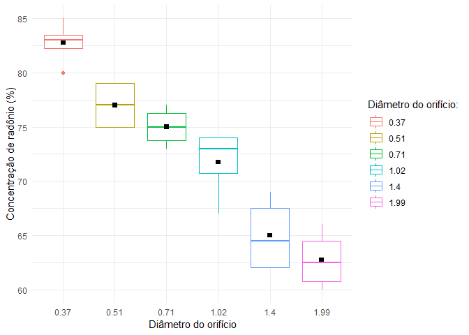

```r
## Diagrama de caixas (ou boxplot):
radon %>%
  ggplot(aes(x = trat, y = resp, colour = trat)) +
  geom_boxplot() +
  stat_summary(fun.y = "mean", colour = "black", size = 2, geom = "point", shape = 15)+
  labs(x = "Diâmetro do orifício",
       y = "Concentração de radônio (%)") +
  scale_colour_discrete(name = "Diâmetro do orifício:") +
  theme_minimal()
```

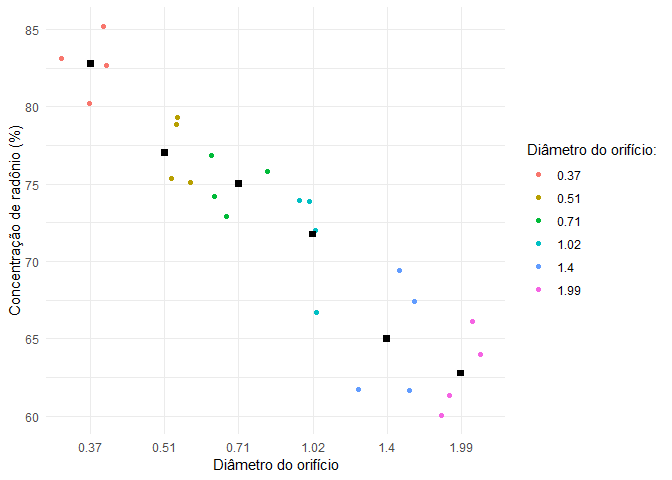

```r
## Diagrama de pontos (ou jitter):
radon %>%
  ggplot(aes(x = trat, y = resp, colour = trat)) +
  geom_jitter() +
  stat_summary(fun.y = "mean", colour = "black", size = 2, geom = "point", shape = 15)+
  labs(x = "Diâmetro do orifício",
       y = "Concentração de radônio (%)") +
  scale_colour_discrete(name = "Diâmetro do orifício:") +
  theme_minimal()
```

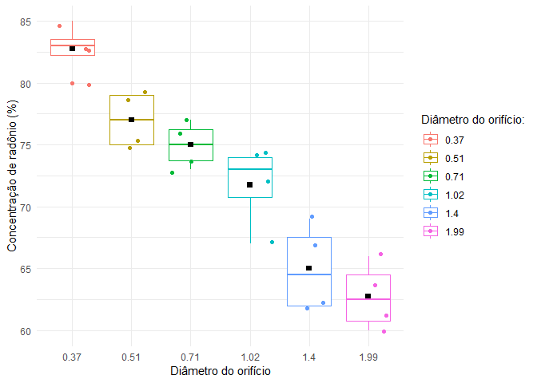

```r
## ambos:
radon %>%
  ggplot(aes(x = trat, y = resp, colour = trat)) +
  geom_boxplot() +
  geom_jitter() +
  stat_summary(fun.y = "mean", colour = "black", size = 2, geom = "point", shape = 15)+
  labs(x = "Diâmetro do orifício",
       y = "Concentração de radônio (%)") +
  scale_colour_discrete(name = "Diâmetro do orifício:") +
  theme_minimal()
```

##### Modelo Estatístico geral:

$$y = f(X_{1}) + \varepsilon(X_{2}),$$

sendo:

- $X_{1}$: uma ou mais variáveis (fatores) cujos valores (níveis) foram controlados durante o experimento e desejamos estudar;
- $X_{2}$: variáveis adicionais qe podem afetar os resultados, mas que sabemos muito ou nada sobre elas. Incorpora todas as fontes de variação no experimento. Por exemplo: medição, fatores não considerados, diferenças entre unidades experimentais, distúrbios em geral no processo.

##### Modelo Estatístico para o problema do radônio:

$$y_{ij}=\mu+\tau_{i}+\varepsilon_{ij}\begin{cases}
i=1,2,\ldots,6 & \textrm{(tratamentos)}\\
j=1,2,\ldots,4 & \textrm{(réplicas)}
\end{cases}$$

sendo:

- $y_{ij}$: a $j$-ésima resposta correspondente ao o $i$-ésimo tratamento;
- $\mu$: o parâmetro (ou efeito) comum a todos os tratamentos denominado *média global* (ou efeito geral de média);
- $\tau_{i}$: o parâmetro (ou efeito) associado ao $i$-ésimo tratamento;
- $\varepsilon_{ij}$: o $j$-ésimo erro aleatório correspondente ao o $i$-ésimo tratamento.

##### Critérios para o teste de hipóteses - Análise de Variância (ANOVA)

Decomposição da soma de quadrados total. O termo ANOVA é derivado da partição da variabilidade total em componentes, segundo o modelo utilizado.

##### ANOVA utilizando o `R`:

```r
# Obtendo as somas de quadrados e seus respectivos graus de liberdade:
radon.av <- aov(formula = resp ~ trat, data = radon)

# Visualizando o resultado:
radon.av
```

```
## Call:
##    aov(formula = resp ~ trat, data = radon)
##
## Terms:
##                     trat Residuals
## Sum of Squares  1133.375   132.250
## Deg. of Freedom        5        18
##
## Residual standard error: 2.710576
## Estimated effects may be unbalanced
```

**Observação**: para conferir os resultados olhem sempre se os graus de liberdade estão corretos, pois é uma forma rápida de ter ideia se você entrou com os dados corretamente na função `aov`. Frequentemente, ocorre que por falta de atenção a variável associada ao tratamento é definida pelo usuário como contínua, quando deveria ser fator. Na dúvida, use a função `is.factor` para fazer a verificação, se ao aplicar a função a saída for `TRUE`, então pode continuar com às análises. No nosso caso, se a variável `trat` não estivesse definida como fator o grau de liberdade do tramento seria `1`, pois estaríamos estimando um modelo de regressão linear simples. Como pode ser visto no bloco que segue:

```r
# as.numeric converte a variável 'trat' (tratamento) em númerico
aov(formula = resp ~ as.numeric(trat), data = radon)
```

```
## Call:
##    aov(formula = resp ~ as.numeric(trat), data = radon)
##
## Terms:
##                 as.numeric(trat) Residuals
## Sum of Squares         1108.0321  157.5929
## Deg. of Freedom                1        22
##
## Residual standard error: 2.676436
## Estimated effects may be unbalanced
```

```r
# Obtendo a ANOVA:
anova(radon.av)
```

```
## Analysis of Variance Table
##
## Response: resp
##           Df  Sum Sq Mean Sq F value   Pr(>F)
## trat       5 1133.38 226.675  30.852 3.16e-08 ***
## Residuals 18  132.25   7.347
## ---
## Signif. codes:  0 '***' 0.001 '**' 0.01 '*' 0.05 '.' 0.1 ' ' 1
```

##### Análise de resíduos:

###### Verificação da adequação do modelo:

- A adequação pode e deve ser feita atráves de análise de resíduos;
- Os resíduos não devem ter nenhuma estrutura aparente e devem ter um comportamento puramente aleatório;
- O modelo estimado é dada por: $\hat{y}_{ij}=\hat{\mu}+\hat{\tau}_{i}=\bar{y}_{..}+\left(\bar{y}_{i.}-\bar{y}_{..}\right)$
- O resíduo é dada por: $e_{ij} = y_{ij} - \hat{y}_{ij}$.

###### Motivo para análise de resíduos

- Detectar qualquer estrutura nas observações
  - *Outliers* (pontos atípicos);
  - Variância não constante;
  - Padrões ao longo do tempo.

###### Gráficos importantes na análise de resíduos:

- Resíduos (`res`) versus ordem de execução;
  - Útil para detectar correlação entre os resíduos;
  - Uma sequência de resíduos positivos ou negativos indica correlação positiva, significa que a suposição de independencia entre os erros não é válida.
- Resíduos versus valores preditos (`vp`);
- Resíduos versus variáveis de interesse;
- Gráfico de probabilidade normal.

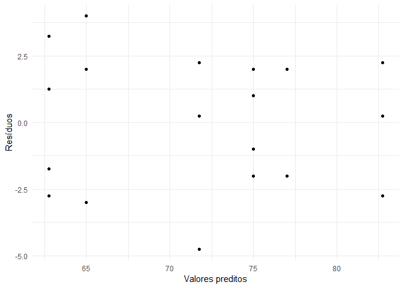

```r
# Adicionando a coluna dos resíduos e valores preditos ao dados:
radon <- radon %>%
  mutate(res = residuals(radon.av), vp = fitted(radon.av))

# Gráfico dos resíduos vs valores preditos:
radon %>%
  ggplot(aes(x = vp, y = res)) +
  geom_point() +
  labs(x = "Valores preditos", y = "Resíduos") +
  theme_minimal()
```

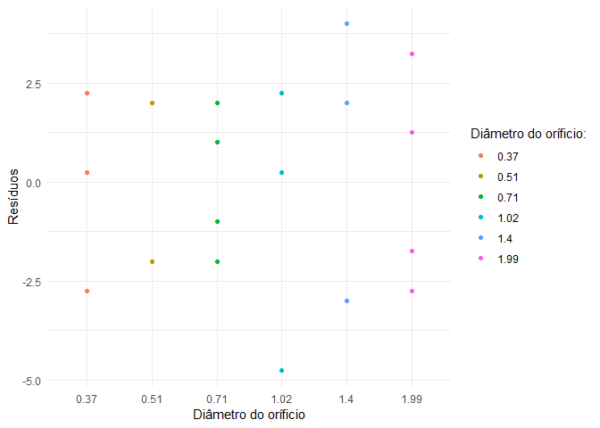

```r
# Gráfico dos resíduos vs variáveis de interesse (tratamento):
radon %>%
  ggplot(aes(x = trat, y = res, colour = trat)) +
  geom_point() +
  scale_color_discrete(name = "Diâmetro do oríficio:") +
  labs(x = "Diâmetro do oríficio", y = "Resíduos") +
  theme_minimal()
```

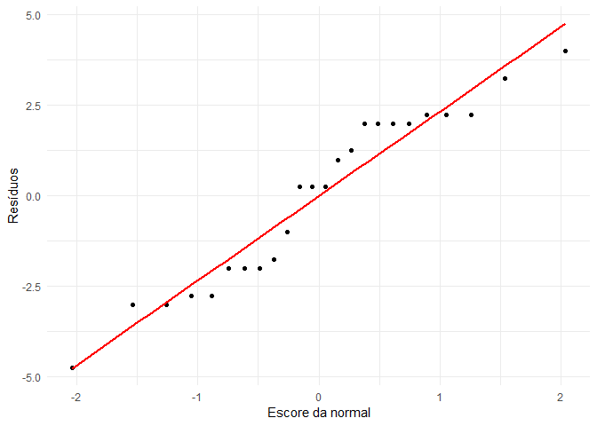

```r
# Gráfico de probabilidade normal:
gpn <- data.frame(qqnorm(radon$res, plot = FALSE))
gpn %>%
  ggplot(aes(x = x, y = y)) +
  geom_point() +
  geom_smooth(method = "lm", se = FALSE, colour = "red") +
  labs(x = "Escore da normal", y = "Resíduos") +
  theme_minimal()
```

**Observação:** note que, os dados são levemente assimétricos. No entanto, o desvio da suposição de normalidade não é acentuado.

###### Suposição de normalidade:

- Em geral devios médios da suposição de normalidade afetam pouco o teste $F$;
- Nesse caso, diz-se que o teste $F$ é robusto a suposição de normalidade.

###### Consequências do devio da suposição de normalidade:

- O nível de significância e o poder do teste diferem levemente dos valores utilizados.

###### Outliers:

- Resíduos com valores muito altos ou muito baixos;
- Podem ser detectados no gráfico de probabilidade normal;
- A presença de um ou mais outliers pode distorcer seriamente os testes;
- Quando possíveis outliers são detectados, uma investigação cuidadosa é necessária;
- Em alguns casos, outliers podem ser mais informativo que o restante dos dados.

###### Análise de resíduos e ANOVA

- Uma vez que os resíduos não apresentam nenhum padrão, os resultados da ANOVA ficam mais confiáveis;
- Se houver algum padrão, então deve-se investigar o porquê de tal comportamento.

###### Passos para análises

1. Análise exploratória dos dados (análise gráfica);
2. Análise de resíduos;

   Objetivos:
   - Experimentos aleatorizados - identificar outliers e possíveis problemas durante a execução do experimento;
   - Experimentos não aleatorizados: checar as suposições para os testes estatísticos.
3. Análise de Variância (ANOVA)
4. Teste de comparação múltipla (por exemplo: teste de Tukey), caso haja diferença diferença entre os tratamentos.

###### Suposições do modelo:

- Distribuição normal dos dados;
- Variância constante nos dados;
- Independência entre os dados.

###### Conclusão:

Sendo assim, podemos interpretar o resultado da ANOVA, que evidencia que devemos rejeitar $H_{0}$ e concluímos que o diâmetro do orifício usado no chuveiro afeta a concentração de radônio liberada.

##### Quais tratamentos são diferentes uns dos outros?

###### Teste de Tukey

```r
radon.tu <- TukeyHSD(radon.av)
radon.tu
```

```
##   Tukey multiple comparisons of means
##     95% family-wise confidence level
##
## Fit: aov(formula = resp ~ trat, data = radon)
##
## $trat
##             diff        lwr         upr     p adj
## 0.51-0.37  -5.75 -11.841234   0.3412336 0.0707511
## 0.71-0.37  -7.75 -13.841234  -1.6587664 0.0084181
## 1.02-0.37 -11.00 -17.091234  -4.9087664 0.0002404
## 1.4-0.37  -17.75 -23.841234 -11.6587664 0.0000004
## 1.99-0.37 -20.00 -26.091234 -13.9087664 0.0000001
## 0.71-0.51  -2.00  -8.091234   4.0912336 0.8968057
## 1.02-0.51  -5.25 -11.341234   0.8412336 0.1153360
## 1.4-0.51  -12.00 -18.091234  -5.9087664 0.0000841
## 1.99-0.51 -14.25 -20.341234  -8.1587664 0.0000089
## 1.02-0.71  -3.25  -9.341234   2.8412336 0.5513482
## 1.4-0.71  -10.00 -16.091234  -3.9087664 0.0007059
## 1.99-0.71 -12.25 -18.341234  -6.1587664 0.0000650
## 1.4-1.02   -6.75 -12.841234  -0.6587664 0.0249971
## 1.99-1.02  -9.00 -15.091234  -2.9087664 0.0021152
## 1.99-1.4   -2.25  -8.341234   3.8412336 0.8432736
```

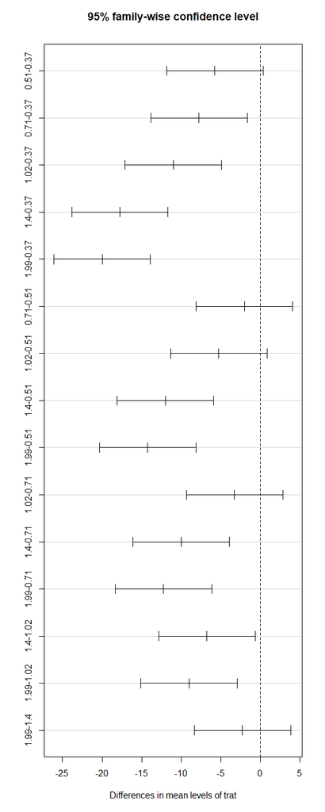

```r
plot(radon.tu)
```

## Problema 2

Quatro projetos diferentes para o circuito de computador digital estão sendo estudados com o objetivo de comparar a quantidade de ruído presente. Foram obtidos os seguintes dados (tradução nossa do exercício 3-12 de Montgomery, 1997,p. 122):

| Projeto | Ruído observado |
| --- | --- |
| 1 | 19 – 20 – 19 – 30 – 08 |
| 2 | 80 – 61 – 73 – 56 – 80 |
| 3 | 47 – 26 – 25 – 35 – 50 |
| 4 | 95 – 46 – 83 – 78 – 97 |

1. A quantidade de ruído é a mesma para todos os projetos? Use $\alpha = 0,05$.
2. Faça análise de resíduos para este experimento. As hipóteses da análise de variância são satisfeita?
3. Que projeto de circuito você escolheria para uso? Baixo ruído é o melhor.

```r
# Carregando os dados (forma do livro):
circuit <- data.frame(trat = 1:4,
                      resp = c("19 20 19 30 08",
                               "80 61 73 56 80",
                               "47 26 25 35 50",
                               "95 46 83 78 97"))
## Conferindo os dados:
circuit
```

```
##   trat           resp
## 1    1 19 20 19 30 08
## 2    2 80 61 73 56 80
## 3    3 47 26 25 35 50
## 4    4 95 46 83 78 97
```

```r
# Organizando os dados para análise:
circuit <- circuit %>%
  separate(resp, into = paste0("resp", 1:5), sep = " ") %>%
  gather(obser, resp, resp1:resp5) %>%
  mutate(trat = as.factor(trat),
         resp = as.integer(resp),
         obser = as.factor(obser)) %>%
  arrange(trat)

## Conferindo os dados:
circuit
```

```
##    trat obser resp
## 1     1 resp1   19
## 2     1 resp2   20
## 3     1 resp3   19
## 4     1 resp4   30
## 5     1 resp5    8
## 6     2 resp1   80
## 7     2 resp2   61
## 8     2 resp3   73
## 9     2 resp4   56
## 10    2 resp5   80
## 11    3 resp1   47
## 12    3 resp2   26
## 13    3 resp3   25
## 14    3 resp4   35
## 15    3 resp5   50
## 16    4 resp1   95
## 17    4 resp2   46
## 18    4 resp3   83
## 19    4 resp4   78
## 20    4 resp5   97
```

## Problema 3

**Exercício 3:** Três marcas de baterias estão sendo estudadas. Suspeita-se que o tempo de vida (em semana) das três são diferentes. Cinco baterias de cada marca são testada produzindo os seguintes resultados (tradução nossa do exercício 3-14 de Montgomery, 1997,p. 122-123):

| Semanas de vida |  |  |
| --- | --- | --- |
| **Marca 1** | **Marca 2** | **Marca 3** |
| 100 | 076 | 108 |
| 096 | 080 | 100 |
| 092 | 075 | 096 |
| 096 | 084 | 098 |
| 092 | 082 | 100 |

1. O tempo de vida das marcas de baterias são diferentes?
2. Faça a análise de resíduos do experimento.
3. Construa o intervalo de 95% de confiança para o tempo médio de vida da bateria 2. Construa o intervalo de 99% de confiança para a diferença entre os tempos médios de vida das marcas de bateria 2 e 3.
4. Qual marca você escolheria para uso? Se o fabricante substituir, sem custo, qualquer bateria que venha falhar em menos de 85 semanas, que porcentagem a empresa esperaria substituir?

```r
# Carregando os dados (forma do livro):
brand <- data.frame(brand1 = c(100, 096, 092, 096, 092),
                    brand2 = c(076, 080, 075, 084, 082),
                    brand3 = c(108, 100, 096, 098,100))

## Conferindo os dados:
brand
```

```
##   brand1 brand2 brand3
## 1    100     76    108
## 2     96     80    100
## 3     92     75     96
## 4     96     84     98
## 5     92     82    100
```

```r
# Organizando os dados para análise:
brand <- brand %>%
  gather(trat, resp, brand1:brand3) %>%
  mutate(trat = as.factor(trat),
         resp = as.integer(resp))

## Conferindo os dados
brand
```

```
##      trat resp
## 1  brand1  100
## 2  brand1   96
## 3  brand1   92
## 4  brand1   96
## 5  brand1   92
## 6  brand2   76
## 7  brand2   80
## 8  brand2   75
## 9  brand2   84
## 10 brand2   82
## 11 brand3  108
## 12 brand3  100
## 13 brand3   96
## 14 brand3   98
## 15 brand3  100
```

## Anexo: texto original dos exercícios

- 3-9 (Montgomery, 1997, p. 120-121): An article in Environment International (Vol. 18, No. 4, 1992) describes an experiment in which the amount of radon released in showers was investigated. Radon-enriched water was used in the experiment, and six different orifice diameters were tested in shower heads. The data from the experiment are shown in the following table:

| Orifice Diameter | Radon Released (%) |
| --- | --- |
| 0.37 | 80 83 83 85 |
| 0.51 | 75 75 79 79 |
| 0.71 | 74 73 76 77 |
| 1.02 | 67 72 74 74 |
| 1.40 | 62 62 67 69 |
| 1.99 | 60 61 64 66 |

1. Does the size of the orifice effect the mean percentage of radon released? Use $\alpha=0,05$.
2. Find the P-value for the $F$ statistic in part (a).
3. Analyze the residuals form this experiment.
4. Find a 95 percent confidence interval on the mean percent of radon released when the orifice diameter is 1.40.
5. Construct a graphical display to compare the treatment means as described in Section 3-5.3. What conclusions can you draw?
- 3-12 (Montgomery, 1997, p. 122): Four different designs for digital computer circuit are being studied to compare the amount of noise present. The following data have been obtained:

| Circuit Design | Noise Observed |
| --- | --- |
| 1 | 19 20 19 30 8 |
| 2 | 80 61 73 56 80 |
| 3 | 47 26 25 35 50 |
| 4 | 95 46 83 78 97 |

1. Is the amount of noise present the same for all four designs? Use $\alpha = 0,05$.
2. Analyze the residuals from this experiment. Are the analysis of variance assumptions satisfied?
3. Which circuit design would you select for use? Low noise is best.
- 3-14 (Montgomery, 1997, p. 122 - 123): Three brands of batteries are under study. It is suspected that the lives (in weeks) of the three brands are different. Five batteries of each brand are tested with the following results:

| Weeks of Life |  |  |
| --- | --- | --- |
| **Brand 1** | **Brand 2** | **Brand 3** |
| 100 | 076 | 108 |
| 096 | 080 | 100 |
| 092 | 075 | 096 |
| 096 | 084 | 098 |
| 092 | 082 | 100 |

1. Are the lives of these brands of batteries different?
2. Analyze the residuals form this experiment.
3. Construct a 95 percent confidence interval estimate on the mean life of battery brand 2. Construct a 99 percent confidence interval estimate on the mean difference between the lives of battery brands 2 and 3.
4. Which brand would you select for use? If the manufacturer will replace without charge any battery that fails in less tha 85 weeks, what percentage would the company expect to replace?

## Referências

- MONTGOMERY, Douglas C.. Design and analysis of experiments. 1997.
- 90% das observações destacadas aqui, foram retiradas das notas de aula da Prof.ª Drª Carla A. Vivacqua.